# Appendix A: Generation of the Bald Head Island meteorological time series

Companion to *Recent increases in male sea turtle hatchling production on a North Carolina, USA beach despite a warming climate

Dr. Matt Ware

University of North Carolina Wilmington Center for Marine Science  
warem@uncw.edu

Paul Hillbrand

Bald Head Island Conservancy  
seaturtle@bhic.org

Ali Johnson

Bald Head Island Conservancy  
alijohnson0123@gmail.com

Dr. Stephanie Kamel

University of North Carolina Wilmington Center for Marine Science  
kamels@uncw.edu

Dr. Beth Darrow

Bald Head Island Conservancy  
darrow@bhic.org

2024-01-26

# 1 DESCRIPTION

Environmental conditions play a critical role in sea turtle embryonic development, controlling incubation temperature, moisture, gas exchange, salinity, and other variables to which the developing embryos must respond. Temperature, in particular, has a long-established link to hatchling sex ratios and mortality rates. The role of moisture from either waves or rainfall has been gaining increased attention in light of climate change concerns as a potential means to mediate feminization and mortality issues at tropical beaches.

*In situ* meteorological observations on Bald Head Island itself have historically been unavailable. The North Carolina State Climate Office began monitoring air temperature, wind speed and direction, barometric pressure, humidity, precipitation, solar radiation, soil temperature, soil moisture, and leaf wetness on the island on 23 June 2015 near the southeast point of the island (33.85$^\circ N$, 77.97$^\circ W$, https://products.climate.ncsu.edu/cardinal/scout/?station=BALD). This station was moved to the southwest point on 1 May 2023 (33.87$^\circ N$, 78.00$^\circ W$, https://products.climate.ncsu.edu/cardinal/scout/?station=BHIC), and operates to the present day.

## 1.1 Libraries

The following libraries were used throughout the subsequent analyses.

```r
library(dplyr)
library(janitor)
library(knitr)
library(leaflet)
library(mgcv)
library(readxl)
library(report)
library(rWind)
library(sf)
library(tmap)
library(tmaptools)
```

# 2 BALD HEAD ISLAND AND NEARBY METEOROLOGY STATIONS

| Type | Station | Start | End | Latitude | Longitude |
| --- | --- | --- | --- | --- | --- |
| Meteorology | BHIC | 2023-05-01 | Present | 33.8633 | -77.9983 |
| Meteorology | BALD | 2015-06-23 | 2023-05-01 | 33.84583 | -77.96583 |
| Meteorology | Brunswick | 2002-02-24 | Present | 33.929 | -78.075 |
| Meteorology | Sunny Point | 2002-01-18 | Present | 34.00377 | -77.99766 |
| Meteorology | Southport | 1892-01-01 | 2016-03-31 | 33.99472 | -78.00778 |

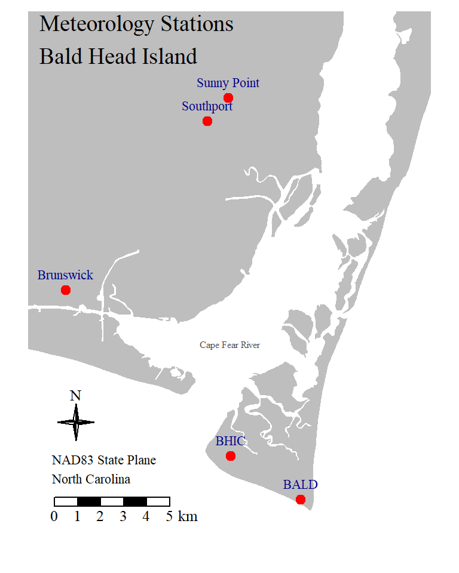

[interactive chart not shown]

# 3 METEOROLOGICAL DATA CORRELATIONS

Since meteorological data is only available on-island starting in 2015, the correlation of the mainland stations with observations on Bald Head Island were investigated in order to extrapolate environmental conditions to a greater percentage of the nesting data.

## 3.1 Maximum Daily Air Temperature

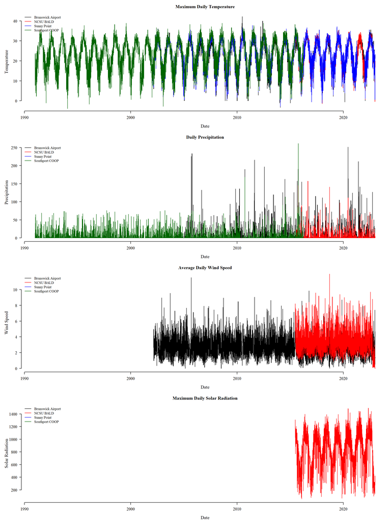

Maximum daily air temperatures were well correlated across each combination of stations. Correlations with Bald Head Island (NCSU BALD 2015-2022) ranged from 92.3% (Southport COOP) to 97.7% (Brunswick Airport).

```
##
##  Pearson's product-moment correlation
##
## data:  corMaxAir$brunswick and corMaxAir$BALD
## t = 234.61, df = 2676, p-value < 2.2e-16
## alternative hypothesis: true correlation is not equal to 0
## 95 percent confidence interval:
##  0.9747191 0.9782362
## sample estimates:
##       cor
## 0.9765427
```

```
##
##  Pearson's product-moment correlation
##
## data:  corMaxAir$southport and corMaxAir$BALD
## t = 38.503, df = 258, p-value < 2.2e-16
## alternative hypothesis: true correlation is not equal to 0
## 95 percent confidence interval:
##  0.9025959 0.9391235
## sample estimates:
##       cor
## 0.9229103
```

```
##
##  Pearson's product-moment correlation
##
## data:  corMaxAir$sunny_point and corMaxAir$BALD
## t = 210.96, df = 2455, p-value < 2.2e-16
## alternative hypothesis: true correlation is not equal to 0
## 95 percent confidence interval:
##  0.9713592 0.9755000
## sample estimates:
##       cor
## 0.9735093
```

```
##
##  Pearson's product-moment correlation
##
## data:  corMaxAir$brunswick and corMaxAir$southport
## t = 153.42, df = 4508, p-value < 2.2e-16
## alternative hypothesis: true correlation is not equal to 0
## 95 percent confidence interval:
##  0.9112915 0.9206810
## sample estimates:
##       cor
## 0.9161118
```

```
##
##  Pearson's product-moment correlation
##
## data:  corMaxAir$brunswick and corMaxAir$sunny_point
## t = 354.76, df = 6974, p-value < 2.2e-16
## alternative hypothesis: true correlation is not equal to 0
## 95 percent confidence interval:
##  0.9721330 0.9745985
## sample estimates:
##       cor
## 0.9733939
```

```
##
##  Pearson's product-moment correlation
##
## data:  corMaxAir$southport and corMaxAir$sunny_point
## t = 164.38, df = 4446, p-value < 2.2e-16
## alternative hypothesis: true correlation is not equal to 0
## 95 percent confidence interval:
##  0.9223978 0.9307087
## sample estimates:
##       cor
## 0.9266664
```

```
##
## Call:
## lm(formula = BALD ~ brunswick, data = corMaxAir)
##
## Residuals:
##     Min      1Q  Median      3Q     Max
## -8.8707 -0.8616  0.0427  0.9131 10.2008
##
## Coefficients:
##              Estimate Std. Error t value Pr(>|t|)
## (Intercept) -0.296370   0.102783  -2.883  0.00396 **
## brunswick    1.007329   0.004294 234.607  < 2e-16 ***
## ---
## Signif. codes:  0 '***' 0.001 '**' 0.01 '*' 0.05 '.' 0.1 ' ' 1
##
## Residual standard error: 1.579 on 2676 degrees of freedom
##   (9010 observations deleted due to missingness)
## Multiple R-squared:  0.9536, Adjusted R-squared:  0.9536
## F-statistic: 5.504e+04 on 1 and 2676 DF,  p-value: < 2.2e-16
```

```
##
## Call:
## lm(formula = BALD ~ southport, data = corMaxAir)
##
## Residuals:
##     Min      1Q  Median      3Q     Max
## -9.2602 -1.6011  0.0769  1.8101  7.6292
##
## Coefficients:
##             Estimate Std. Error t value Pr(>|t|)
## (Intercept)  0.27208    0.60337   0.451    0.652
## southport    0.89263    0.02318  38.503   <2e-16 ***
## ---
## Signif. codes:  0 '***' 0.001 '**' 0.01 '*' 0.05 '.' 0.1 ' ' 1
##
## Residual standard error: 2.799 on 258 degrees of freedom
##   (11428 observations deleted due to missingness)
## Multiple R-squared:  0.8518, Adjusted R-squared:  0.8512
## F-statistic:  1482 on 1 and 258 DF,  p-value: < 2.2e-16
```

```
##
## Call:
## lm(formula = BALD ~ sunny_point, data = corMaxAir)
##
## Residuals:
##     Min      1Q  Median      3Q     Max
## -7.6511 -0.9373  0.1489  1.0842  6.7229
##
## Coefficients:
##              Estimate Std. Error t value Pr(>|t|)
## (Intercept) -0.673686   0.115103  -5.853 5.48e-09 ***
## sunny_point  0.994473   0.004714 210.960  < 2e-16 ***
## ---
## Signif. codes:  0 '***' 0.001 '**' 0.01 '*' 0.05 '.' 0.1 ' ' 1
##
## Residual standard error: 1.693 on 2455 degrees of freedom
##   (9231 observations deleted due to missingness)
## Multiple R-squared:  0.9477, Adjusted R-squared:  0.9477
## F-statistic: 4.45e+04 on 1 and 2455 DF,  p-value: < 2.2e-16
```

```
##
## Call:
## lm(formula = brunswick ~ southport, data = corMaxAir)
##
## Residuals:
##      Min       1Q   Median       3Q      Max
## -17.9903  -1.6768  -0.1139   1.6063  15.2814
##
## Coefficients:
##             Estimate Std. Error t value Pr(>|t|)
## (Intercept) 0.793775   0.143450   5.533 3.32e-08 ***
## southport   0.879590   0.005733 153.419  < 2e-16 ***
## ---
## Signif. codes:  0 '***' 0.001 '**' 0.01 '*' 0.05 '.' 0.1 ' ' 1
##
## Residual standard error: 2.946 on 4508 degrees of freedom
##   (7178 observations deleted due to missingness)
## Multiple R-squared:  0.8393, Adjusted R-squared:  0.8392
## F-statistic: 2.354e+04 on 1 and 4508 DF,  p-value: < 2.2e-16
```

```
##
## Call:
## lm(formula = brunswick ~ sunny_point, data = corMaxAir)
##
## Residuals:
##      Min       1Q   Median       3Q      Max
## -12.8417  -0.9961  -0.0398   0.9165  14.1234
##
## Coefficients:
##              Estimate Std. Error t value Pr(>|t|)
## (Intercept) -0.252577   0.065945   -3.83 0.000129 ***
## sunny_point  0.976118   0.002752  354.76  < 2e-16 ***
## ---
## Signif. codes:  0 '***' 0.001 '**' 0.01 '*' 0.05 '.' 0.1 ' ' 1
##
## Residual standard error: 1.692 on 6974 degrees of freedom
##   (4712 observations deleted due to missingness)
## Multiple R-squared:  0.9475, Adjusted R-squared:  0.9475
## F-statistic: 1.259e+05 on 1 and 6974 DF,  p-value: < 2.2e-16
```

```
##
## Call:
## lm(formula = southport ~ sunny_point, data = corMaxAir)
##
## Residuals:
##      Min       1Q   Median       3Q      Max
## -15.9078  -1.1386   0.1922   1.3717  18.0501
##
## Coefficients:
##             Estimate Std. Error t value Pr(>|t|)
## (Intercept) 1.991052   0.139050   14.32   <2e-16 ***
## sunny_point 0.962613   0.005856  164.38   <2e-16 ***
## ---
## Signif. codes:  0 '***' 0.001 '**' 0.01 '*' 0.05 '.' 0.1 ' ' 1
##
## Residual standard error: 2.883 on 4446 degrees of freedom
##   (7240 observations deleted due to missingness)
## Multiple R-squared:  0.8587, Adjusted R-squared:  0.8587
## F-statistic: 2.702e+04 on 1 and 4446 DF,  p-value: < 2.2e-16
```

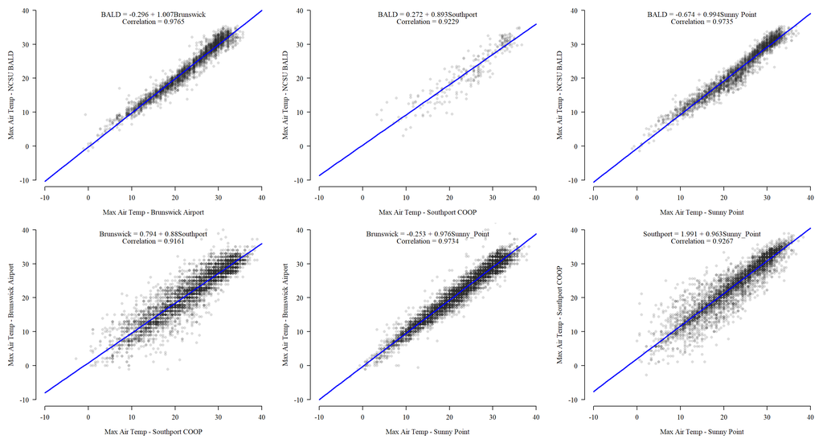

## 3.2 Minimum Daily Air Temperature

Minimum daily air temperatures were equally well correlated across each combination of stations. Correlations with Bald Head Island (NCSU BALD 2015-2022) ranged from 93.5% (Southport COOP) to 97.7% (Sunny Point).

```
##
##  Pearson's product-moment correlation
##
## data:  corMinAir$brunswick and corMinAir$BALD
## t = 174.47, df = 2676, p-value < 2.2e-16
## alternative hypothesis: true correlation is not equal to 0
## 95 percent confidence interval:
##  0.9555713 0.9617006
## sample estimates:
##       cor
## 0.9587473
```

```
##
##  Pearson's product-moment correlation
##
## data:  corMinAir$southport and corMinAir$BALD
## t = 41.743, df = 250, p-value < 2.2e-16
## alternative hypothesis: true correlation is not equal to 0
## 95 percent confidence interval:
##  0.9176304 0.9490603
## sample estimates:
##       cor
## 0.9351614
```

```
##
##  Pearson's product-moment correlation
##
## data:  corMinAir$sunny_point and corMinAir$BALD
## t = 225.92, df = 2455, p-value < 2.2e-16
## alternative hypothesis: true correlation is not equal to 0
## 95 percent confidence interval:
##  0.9748965 0.9785315
## sample estimates:
##       cor
## 0.9767842
```

```
##
##  Pearson's product-moment correlation
##
## data:  corMinAir$brunswick and corMinAir$southport
## t = 184.04, df = 4510, p-value < 2.2e-16
## alternative hypothesis: true correlation is not equal to 0
## 95 percent confidence interval:
##  0.9358858 0.9427486
## sample estimates:
##       cor
## 0.9394112
```

```
##
##  Pearson's product-moment correlation
##
## data:  corMinAir$brunswick and corMinAir$sunny_point
## t = 336.2, df = 6971, p-value < 2.2e-16
## alternative hypothesis: true correlation is not equal to 0
## 95 percent confidence interval:
##  0.9691250 0.9718534
## sample estimates:
##       cor
## 0.9705202
```

```
##
##  Pearson's product-moment correlation
##
## data:  corMinAir$southport and corMinAir$sunny_point
## t = 229.15, df = 4444, p-value < 2.2e-16
## alternative hypothesis: true correlation is not equal to 0
## 95 percent confidence interval:
##  0.9578343 0.9624252
## sample estimates:
##       cor
## 0.9601946
```

```
##
## Call:
## lm(formula = BALD ~ brunswick, data = corMinAir)
##
## Residuals:
##     Min      1Q  Median      3Q     Max
## -11.236  -1.006  -0.241   0.604  33.332
##
## Coefficients:
##             Estimate Std. Error t value Pr(>|t|)
## (Intercept) 2.768468   0.086240    32.1   <2e-16 ***
## brunswick   0.918920   0.005267   174.5   <2e-16 ***
## ---
## Signif. codes:  0 '***' 0.001 '**' 0.01 '*' 0.05 '.' 0.1 ' ' 1
##
## Residual standard error: 2.308 on 2676 degrees of freedom
##   (9010 observations deleted due to missingness)
## Multiple R-squared:  0.9192, Adjusted R-squared:  0.9192
## F-statistic: 3.044e+04 on 1 and 2676 DF,  p-value: < 2.2e-16
```

```
##
## Call:
## lm(formula = BALD ~ southport, data = corMinAir)
##
## Residuals:
##     Min      1Q  Median      3Q     Max
## -8.5014 -1.9400 -0.1126  1.5735 13.2662
##
## Coefficients:
##             Estimate Std. Error t value Pr(>|t|)
## (Intercept)  4.50111    0.33185   13.56   <2e-16 ***
## southport    0.86889    0.02082   41.74   <2e-16 ***
## ---
## Signif. codes:  0 '***' 0.001 '**' 0.01 '*' 0.05 '.' 0.1 ' ' 1
##
## Residual standard error: 2.864 on 250 degrees of freedom
##   (11436 observations deleted due to missingness)
## Multiple R-squared:  0.8745, Adjusted R-squared:  0.874
## F-statistic:  1742 on 1 and 250 DF,  p-value: < 2.2e-16
```

```
##
## Call:
## lm(formula = BALD ~ sunny_point, data = corMinAir)
##
## Residuals:
##     Min      1Q  Median      3Q     Max
## -7.4608 -1.1743 -0.1743  1.0554  7.6094
##
## Coefficients:
##             Estimate Std. Error t value Pr(>|t|)
## (Intercept) 3.333854   0.064382   51.78   <2e-16 ***
## sunny_point 0.918915   0.004067  225.92   <2e-16 ***
## ---
## Signif. codes:  0 '***' 0.001 '**' 0.01 '*' 0.05 '.' 0.1 ' ' 1
##
## Residual standard error: 1.759 on 2455 degrees of freedom
##   (9231 observations deleted due to missingness)
## Multiple R-squared:  0.9541, Adjusted R-squared:  0.9541
## F-statistic: 5.104e+04 on 1 and 2455 DF,  p-value: < 2.2e-16
```

```
##
## Call:
## lm(formula = brunswick ~ southport, data = corMinAir)
##
## Residuals:
##     Min      1Q  Median      3Q     Max
## -36.074  -1.469  -0.209   1.331  14.217
##
## Coefficients:
##             Estimate Std. Error t value Pr(>|t|)
## (Intercept) 2.073222   0.073770    28.1   <2e-16 ***
## southport   0.916031   0.004977   184.0   <2e-16 ***
## ---
## Signif. codes:  0 '***' 0.001 '**' 0.01 '*' 0.05 '.' 0.1 ' ' 1
##
## Residual standard error: 2.95 on 4510 degrees of freedom
##   (7176 observations deleted due to missingness)
## Multiple R-squared:  0.8825, Adjusted R-squared:  0.8825
## F-statistic: 3.387e+04 on 1 and 4510 DF,  p-value: < 2.2e-16
```

```
##
## Call:
## lm(formula = brunswick ~ sunny_point, data = corMinAir)
##
## Residuals:
##     Min      1Q  Median      3Q     Max
## -33.979  -0.963  -0.021   1.042  15.271
##
## Coefficients:
##             Estimate Std. Error t value Pr(>|t|)
## (Intercept) 0.800683   0.044550   17.97   <2e-16 ***
## sunny_point 0.965783   0.002873  336.20   <2e-16 ***
## ---
## Signif. codes:  0 '***' 0.001 '**' 0.01 '*' 0.05 '.' 0.1 ' ' 1
##
## Residual standard error: 2.073 on 6971 degrees of freedom
##   (4715 observations deleted due to missingness)
## Multiple R-squared:  0.9419, Adjusted R-squared:  0.9419
## F-statistic: 1.13e+05 on 1 and 6971 DF,  p-value: < 2.2e-16
```

```
##
## Call:
## lm(formula = southport ~ sunny_point, data = corMinAir)
##
## Residuals:
##      Min       1Q   Median       3Q      Max
## -15.2178  -0.8669   0.2961   1.0083  14.0423
##
## Coefficients:
##              Estimate Std. Error t value Pr(>|t|)
## (Intercept) -0.720921   0.066002  -10.92   <2e-16 ***
## sunny_point  0.987397   0.004309  229.15   <2e-16 ***
## ---
## Signif. codes:  0 '***' 0.001 '**' 0.01 '*' 0.05 '.' 0.1 ' ' 1
##
## Residual standard error: 2.467 on 4444 degrees of freedom
##   (7242 observations deleted due to missingness)
## Multiple R-squared:  0.922,  Adjusted R-squared:  0.922
## F-statistic: 5.251e+04 on 1 and 4444 DF,  p-value: < 2.2e-16
```

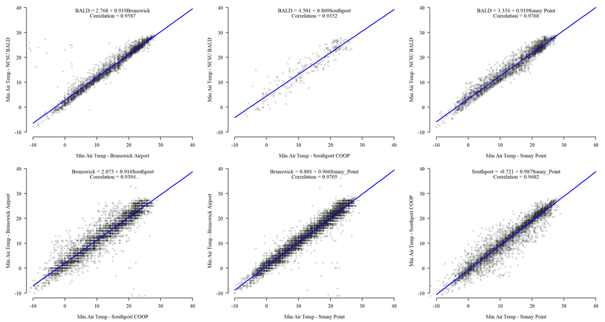

## 3.3 Average Daily Air Temperature

As the Southport COOP station does not report daily average temperatures, the next comparison does not include this station. Average daily air temperatures were extremely well correlated across each combination of stations. Correlations with Bald Head Island (NCSU BALD 2015-2022) were 99.1% (Brunswick Airport) and 98.8% (Sunny Point).

```
##
##  Pearson's product-moment correlation
##
## data:  corAvgAir$brunswick and corAvgAir$BALD
## t = 373, df = 2676, p-value < 2.2e-16
## alternative hypothesis: true correlation is not equal to 0
## 95 percent confidence interval:
##  0.9897770 0.9912086
## sample estimates:
##       cor
## 0.9905197
```

```
##
##  Pearson's product-moment correlation
##
## data:  corAvgAir$sunny_point and corAvgAir$BALD
## t = 323.02, df = 2455, p-value < 2.2e-16
## alternative hypothesis: true correlation is not equal to 0
## 95 percent confidence interval:
##  0.9874937 0.9893145
## sample estimates:
##       cor
## 0.9884397
```

```
##
##  Pearson's product-moment correlation
##
## data:  corAvgAir$brunswick and corAvgAir$sunny_point
## t = 492, df = 6974, p-value < 2.2e-16
## alternative hypothesis: true correlation is not equal to 0
## 95 percent confidence interval:
##  0.9852259 0.9865409
## sample estimates:
##       cor
## 0.9858986
```

```
##
## Call:
## lm(formula = BALD ~ brunswick, data = corAvgAir)
##
## Residuals:
##     Min      1Q  Median      3Q     Max
## -4.9789 -0.4935 -0.0394  0.4343 15.0614
##
## Coefficients:
##             Estimate Std. Error t value Pr(>|t|)
## (Intercept) 1.083745   0.052421   20.67   <2e-16 ***
## brunswick   0.982367   0.002634  373.00   <2e-16 ***
## ---
## Signif. codes:  0 '***' 0.001 '**' 0.01 '*' 0.05 '.' 0.1 ' ' 1
##
## Residual standard error: 1.022 on 2676 degrees of freedom
##   (9010 observations deleted due to missingness)
## Multiple R-squared:  0.9811, Adjusted R-squared:  0.9811
## F-statistic: 1.391e+05 on 1 and 2676 DF,  p-value: < 2.2e-16
```

```
##
## Call:
## lm(formula = BALD ~ sunny_point, data = corAvgAir)
##
## Residuals:
##     Min      1Q  Median      3Q     Max
## -6.1054 -0.4848  0.1354  0.7212  4.0551
##
## Coefficients:
##             Estimate Std. Error t value Pr(>|t|)
## (Intercept) 1.401062   0.059151   23.69   <2e-16 ***
## sunny_point 0.961375   0.002976  323.02   <2e-16 ***
## ---
## Signif. codes:  0 '***' 0.001 '**' 0.01 '*' 0.05 '.' 0.1 ' ' 1
##
## Residual standard error: 1.141 on 2455 degrees of freedom
##   (9231 observations deleted due to missingness)
## Multiple R-squared:  0.977,  Adjusted R-squared:  0.977
## F-statistic: 1.043e+05 on 1 and 2455 DF,  p-value: < 2.2e-16
```

```
##
## Call:
## lm(formula = brunswick ~ sunny_point, data = corAvgAir)
##
## Residuals:
##      Min       1Q   Median       3Q      Max
## -14.8861  -0.7175   0.0868   0.6861  12.0682
##
## Coefficients:
##             Estimate Std. Error t value Pr(>|t|)
## (Intercept) 0.089811   0.038859   2.311   0.0209 *
## sunny_point 0.981203   0.001994 491.999   <2e-16 ***
## ---
## Signif. codes:  0 '***' 0.001 '**' 0.01 '*' 0.05 '.' 0.1 ' ' 1
##
## Residual standard error: 1.301 on 6974 degrees of freedom
##   (4712 observations deleted due to missingness)
## Multiple R-squared:  0.972,  Adjusted R-squared:  0.972
## F-statistic: 2.421e+05 on 1 and 6974 DF,  p-value: < 2.2e-16
```

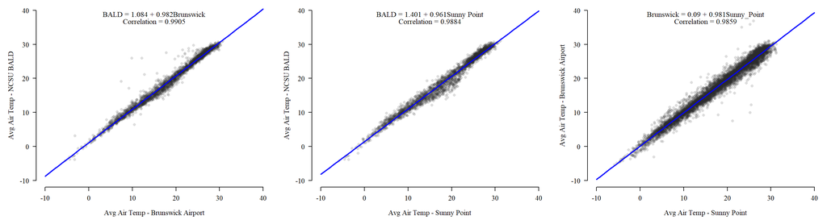

## 3.4 Daily Precipitation

As the Sunny Point station does not report precipitation, the next comparison does not include this station. Daily total precipitation was correlated between NCSU BALD and Brunswick Airport (74.4%) but not with Southport COOP (0%). **Precipitation observations from Southport COOP therefore cannot be extrapolated to Bald Head Island.**

```
##
##  Pearson's product-moment correlation
##
## data:  corPrecip$brunswick and corPrecip$BALD
## t = 57.706, df = 2679, p-value < 2.2e-16
## alternative hypothesis: true correlation is not equal to 0
## 95 percent confidence interval:
##  0.7270547 0.7608368
## sample estimates:
##       cor
## 0.7444218
```

```
##
##  Pearson's product-moment correlation
##
## data:  corPrecip$southport and corPrecip$BALD
## t = -0.092019, df = 268, p-value = 0.9268
## alternative hypothesis: true correlation is not equal to 0
## 95 percent confidence interval:
##  -0.1249129  0.1138314
## sample estimates:
##          cor
## -0.005620842
```

```
##
##  Pearson's product-moment correlation
##
## data:  corPrecip$brunswick and corPrecip$southport
## t = 30.706, df = 4889, p-value < 2.2e-16
## alternative hypothesis: true correlation is not equal to 0
## 95 percent confidence interval:
##  0.3783263 0.4253228
## sample estimates:
##       cor
## 0.4020894
```

```
##
## Call:
## lm(formula = BALD ~ brunswick, data = corPrecip[corPrecip$brunswick_binary ==
##     1, ])
##
## Residuals:
##     Min      1Q  Median      3Q     Max
## -68.283  -3.614  -2.583   1.281 110.638
##
## Coefficients:
##             Estimate Std. Error t value Pr(>|t|)
## (Intercept)  2.79016    0.51036   5.467 6.03e-08 ***
## brunswick    0.42717    0.01559  27.408  < 2e-16 ***
## ---
## Signif. codes:  0 '***' 0.001 '**' 0.01 '*' 0.05 '.' 0.1 ' ' 1
##
## Residual standard error: 12.55 on 846 degrees of freedom
##   (5422 observations deleted due to missingness)
## Multiple R-squared:  0.4703, Adjusted R-squared:  0.4697
## F-statistic: 751.2 on 1 and 846 DF,  p-value: < 2.2e-16
```

```
##
## Call:
## lm(formula = BALD ~ southport, data = corPrecip)
##
## Residuals:
##     Min      1Q  Median      3Q     Max
##  -5.686  -5.686  -5.686  -3.652 139.344
##
## Coefficients:
##              Estimate Std. Error t value Pr(>|t|)
## (Intercept)  5.686077   1.049829   5.416 1.35e-07 ***
## southport   -0.004257   0.046264  -0.092    0.927
## ---
## Signif. codes:  0 '***' 0.001 '**' 0.01 '*' 0.05 '.' 0.1 ' ' 1
##
## Residual standard error: 16.91 on 268 degrees of freedom
##   (11418 observations deleted due to missingness)
## Multiple R-squared:  3.159e-05,  Adjusted R-squared:  -0.0037
## F-statistic: 0.008467 on 1 and 268 DF,  p-value: 0.9268
```

```
##
## Call:
## lm(formula = brunswick ~ southport, data = corPrecip)
##
## Residuals:
##      Min       1Q   Median       3Q      Max
## -170.787   -2.276   -2.276   -2.276  213.624
##
## Coefficients:
##             Estimate Std. Error t value Pr(>|t|)
## (Intercept)  2.27579    0.18329   12.42   <2e-16 ***
## southport    0.52778    0.01719   30.71   <2e-16 ***
## ---
## Signif. codes:  0 '***' 0.001 '**' 0.01 '*' 0.05 '.' 0.1 ' ' 1
##
## Residual standard error: 12.32 on 4889 degrees of freedom
##   (6797 observations deleted due to missingness)
## Multiple R-squared:  0.1617, Adjusted R-squared:  0.1615
## F-statistic: 942.9 on 1 and 4889 DF,  p-value: < 2.2e-16
```

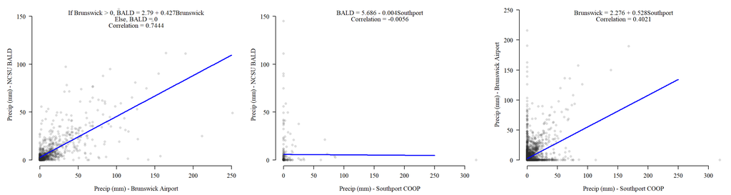

## 3.5 Average Wind Speed

Wind speed is only available from the Brunswick Airport and Bald Head Islands stations. These stations showed good agreement with a correlation of 80.6%. Correlations in wind direction were not assessed here.

```
##
##  Pearson's product-moment correlation
##
## data:  corWindSpeed$brunswick and corWindSpeed$BALD
## t = 70.445, df = 2679, p-value < 2.2e-16
## alternative hypothesis: true correlation is not equal to 0
## 95 percent confidence interval:
##  0.7921731 0.8187414
## sample estimates:
##       cor
## 0.8058625
```

```
##
## Call:
## lm(formula = BALD ~ brunswick, data = corWindSpeed)
##
## Residuals:
##     Min      1Q  Median      3Q     Max
## -6.8436 -0.3936  0.0914  0.5476  4.3839
##
## Coefficients:
##             Estimate Std. Error t value Pr(>|t|)
## (Intercept)  0.79696    0.04106   19.41   <2e-16 ***
## brunswick    0.97664    0.01386   70.44   <2e-16 ***
## ---
## Signif. codes:  0 '***' 0.001 '**' 0.01 '*' 0.05 '.' 0.1 ' ' 1
##
## Residual standard error: 0.9315 on 2679 degrees of freedom
## Multiple R-squared:  0.6494, Adjusted R-squared:  0.6493
## F-statistic:  4963 on 1 and 2679 DF,  p-value: < 2.2e-16
```

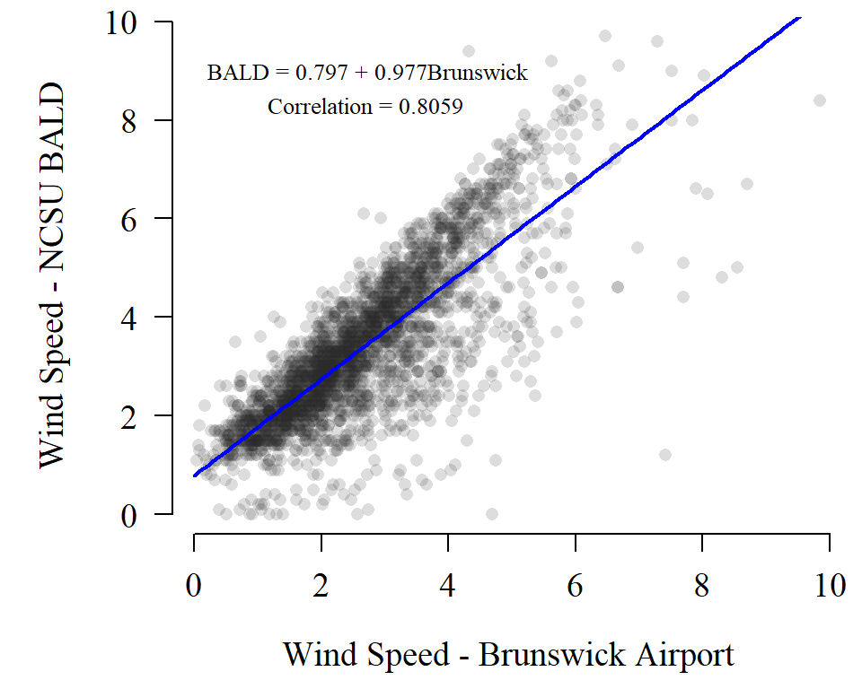

# 4 METEOROLOGICAL TIME SERIES

Using these relationships, a single time series record was created to cover the Bald Head Island nesting dataset with as much meteorological information as possible. Data after 23 June 2015 was extracted from the NCSU Bald Head Island stations. Data prior to the NCSU installation was extrapolated from the Brunswick Airport, Sunny Point, or Southport stations (in that order) using the above statistical relationships as station data was available.

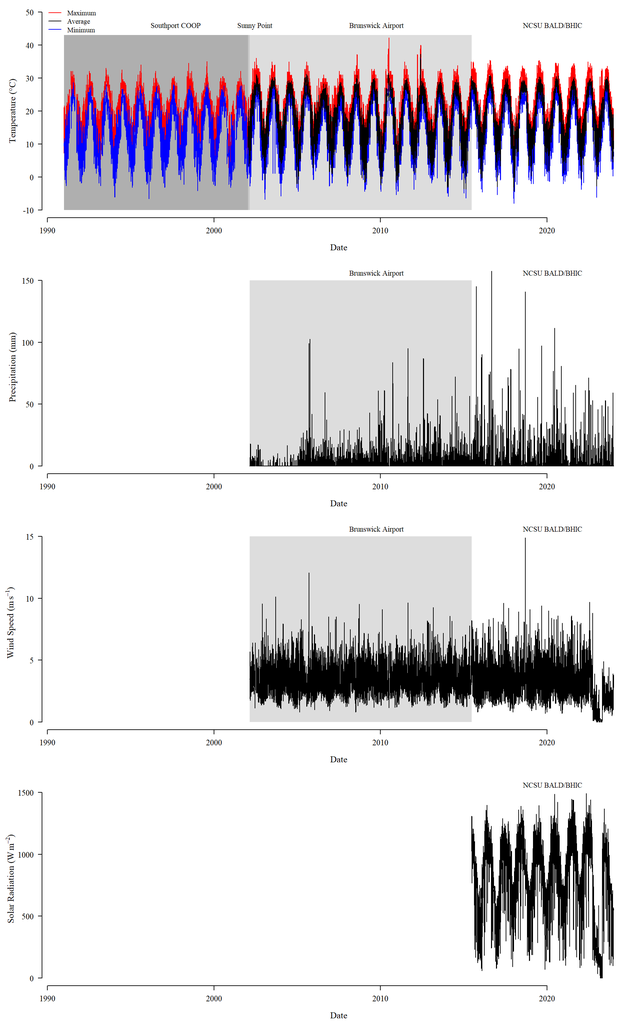

# 5 ANNUAL TRENDS

Full-year meteorological conditions for Bald Head Island from 1991 - 2023

| year | meanAvgAir | sdAvgAir | missAvgTemp | meanMaxAir | sdMaxAir | maxMaxAir | missMaxTemp | meanPrecip | sdPrecip | maxPrecip | missPrecip | meanWindSpeed | sdWindSpeed | maxWindSpeed | meanWindDir | missWind | meanSolarRad | sdSolarRad | missSolarRad |
| --- | --- | --- | --- | --- | --- | --- | --- | --- | --- | --- | --- | --- | --- | --- | --- | --- | --- | --- | --- |
| 1991 | NA | NA | 100.0 | 20.49 | 6.69 | 32.1 | 15.9 | NA | NA | NA | 100.0 | NA | NA | NA | NA | 100.0 | NA | NA | 100.0 |
| 1992 | NA | NA | 100.0 | 20.38 | 6.17 | 32.1 | 3.6 | NA | NA | NA | 100.0 | NA | NA | NA | NA | 100.0 | NA | NA | 100.0 |
| 1993 | NA | NA | 100.0 | 20.80 | 6.94 | 33.0 | 1.9 | NA | NA | NA | 100.0 | NA | NA | NA | NA | 100.0 | NA | NA | 100.0 |
| 1994 | NA | NA | 100.0 | 21.00 | 6.06 | 32.5 | 0.5 | NA | NA | NA | 100.0 | NA | NA | NA | NA | 100.0 | NA | NA | 100.0 |
| 1995 | NA | NA | 100.0 | 20.68 | 6.85 | 34.0 | 0.0 | NA | NA | NA | 100.0 | NA | NA | NA | NA | 100.0 | NA | NA | 100.0 |
| 1996 | NA | NA | 100.0 | 20.34 | 6.75 | 32.1 | 0.5 | NA | NA | NA | 100.0 | NA | NA | NA | NA | 100.0 | NA | NA | 100.0 |
| 1997 | NA | NA | 100.0 | 20.56 | 6.12 | 30.5 | 1.4 | NA | NA | NA | 100.0 | NA | NA | NA | NA | 100.0 | NA | NA | 100.0 |
| 1998 | NA | NA | 100.0 | 21.65 | 6.46 | 34.5 | 0.3 | NA | NA | NA | 100.0 | NA | NA | NA | NA | 100.0 | NA | NA | 100.0 |
| 1999 | NA | NA | 100.0 | 20.95 | 6.20 | 35.0 | 0.5 | NA | NA | NA | 100.0 | NA | NA | NA | NA | 100.0 | NA | NA | 100.0 |
| 2000 | NA | NA | 100.0 | 20.26 | 7.06 | 30.5 | 8.2 | NA | NA | NA | 100.0 | NA | NA | NA | NA | 100.0 | NA | NA | 100.0 |
| 2001 | NA | NA | 100.0 | 21.21 | 6.05 | 32.1 | 8.8 | NA | NA | NA | 100.0 | NA | NA | NA | NA | 100.0 | NA | NA | 100.0 |
| 2002 | 20.28 | 6.95 | 4.7 | 22.78 | 7.29 | 36.0 | 0.0 | NA | NA | NA | 29.6 | NA | NA | NA | NA | 29.6 | NA | NA | 100.0 |
| 2003 | 19.74 | 7.56 | 0.0 | 22.55 | 7.60 | 34.9 | 0.0 | 0.23 | 1.11 | 10.05 | 0.3 | 3.55 | 1.31 | 10.13 | 259.85 | 1.9 | NA | NA | 100.0 |
| 2004 | 18.96 | 7.35 | 0.0 | 21.71 | 7.27 | 34.9 | 0.0 | 0.23 | 1.35 | 16.67 | 1.6 | 3.59 | 1.34 | 7.94 | 244.98 | 1.9 | NA | NA | 100.0 |
| 2005 | 18.43 | 7.98 | 3.3 | 21.78 | 7.60 | 34.9 | 3.3 | 3.42 | 9.83 | 102.46 | 1.6 | 3.57 | 1.45 | 12.06 | 293.22 | 1.6 | NA | NA | 100.0 |
| 2006 | 18.89 | 5.57 | 2.5 | 22.48 | 5.24 | 31.0 | 2.5 | 2.35 | 5.54 | 59.41 | 0.0 | 3.38 | 1.25 | 8.52 | 246.73 | 0.0 | NA | NA | 100.0 |
| 2007 | 18.05 | 6.63 | 0.0 | 21.68 | 6.38 | 32.1 | 0.0 | 1.60 | 3.92 | 29.69 | 0.0 | 3.51 | 1.21 | 8.51 | 253.53 | 0.0 | NA | NA | 100.0 |
| 2008 | 18.22 | 7.49 | 0.3 | 22.19 | 7.59 | 37.2 | 0.3 | 2.05 | 4.70 | 31.21 | 0.3 | 3.59 | 1.37 | 9.53 | 246.62 | 0.3 | NA | NA | 100.0 |
| 2009 | 18.03 | 7.96 | 0.0 | 21.15 | 7.83 | 32.7 | 0.0 | 2.89 | 6.63 | 60.71 | 0.0 | 3.60 | 1.22 | 7.28 | 260.82 | 0.0 | NA | NA | 100.0 |
| 2010 | 16.74 | 9.29 | 6.3 | 20.27 | 9.36 | 42.2 | 6.3 | 2.74 | 8.61 | 83.81 | 6.3 | 3.57 | 1.26 | 9.09 | 264.56 | 6.3 | NA | NA | 100.0 |
| 2011 | 17.92 | 7.88 | 3.0 | 21.37 | 7.71 | 34.9 | 3.0 | 3.01 | 8.27 | 94.98 | 3.0 | 3.61 | 1.20 | 9.65 | 239.31 | 3.0 | NA | NA | 100.0 |
| 2012 | 18.33 | 7.19 | 1.1 | 21.96 | 7.10 | 40.0 | 1.1 | 3.13 | 7.87 | 86.95 | 1.1 | 3.50 | 1.29 | 8.18 | 259.05 | 1.1 | NA | NA | 100.0 |
| 2013 | 17.70 | 7.64 | 0.0 | 21.18 | 7.25 | 32.7 | 0.0 | 2.84 | 6.59 | 53.87 | 0.0 | 3.59 | 1.24 | 9.25 | 279.51 | 0.0 | NA | NA | 100.0 |
| 2014 | 17.79 | 8.02 | 0.0 | 21.25 | 7.78 | 33.8 | 0.0 | 3.40 | 7.58 | 72.20 | 0.0 | 3.55 | 1.22 | 8.56 | 283.74 | 0.0 | NA | NA | 100.0 |
| 2015 | 19.14 | 7.67 | 0.5 | 22.49 | 7.51 | 34.9 | 0.5 | 4.54 | 13.14 | 145.03 | 0.5 | 3.64 | 1.50 | 8.20 | 198.31 | 0.5 | NA | NA | 54.2 |
| 2016 | 19.12 | 7.82 | 0.0 | 22.69 | 7.69 | 35.4 | 0.0 | 3.97 | 14.08 | 157.48 | 0.0 | 3.50 | 1.51 | 8.40 | 190.89 | 0.0 | 827.24 | 274.76 | 10.4 |
| 2017 | 19.33 | 7.19 | 0.3 | 22.86 | 7.14 | 33.7 | 0.3 | 3.14 | 9.83 | 78.23 | 0.3 | 3.52 | 1.56 | 9.60 | 195.58 | 0.3 | 834.60 | 248.68 | 8.8 |
| 2018 | 18.34 | 8.34 | 7.7 | 21.73 | 8.15 | 33.7 | 7.7 | 4.10 | 12.22 | 140.97 | 7.7 | 3.54 | 1.56 | 14.90 | 186.44 | 7.7 | 836.24 | 240.73 | 8.8 |
| 2019 | 19.31 | 7.43 | 0.8 | 22.88 | 7.36 | 35.3 | 0.8 | 2.72 | 8.44 | 97.28 | 0.3 | 3.40 | 1.49 | 9.40 | 180.82 | 0.3 | 833.47 | 240.50 | 1.4 |
| 2020 | 19.33 | 7.01 | 0.5 | 22.84 | 6.89 | 34.6 | 0.5 | 3.73 | 11.11 | 111.51 | 0.5 | 3.41 | 1.50 | 9.00 | 189.03 | 0.5 | 847.80 | 240.49 | 1.1 |
| 2021 | 18.85 | 7.27 | 0.5 | 22.54 | 7.31 | 34.4 | 0.5 | 2.61 | 7.97 | 65.28 | 0.5 | 3.32 | 1.46 | 8.60 | 190.35 | 0.5 | 874.75 | 271.34 | 0.5 |
| 2022 | 18.92 | 7.58 | 1.1 | 22.54 | 7.34 | 34.9 | 1.1 | 2.61 | 8.69 | 71.37 | 1.1 | 3.03 | 1.86 | 9.70 | 183.43 | 1.1 | 839.75 | 343.90 | 1.6 |
| 2023 | 19.22 | 6.67 | 0.0 | 23.06 | 6.60 | 33.6 | 0.0 | 2.70 | 7.80 | 59.18 | 0.0 | 1.50 | 1.01 | 4.90 | 187.88 | 6.0 | 574.99 | 377.72 | 0.0 |

Turtle season (May - October) meteorological conditions for Bald Head Island from 1991 - 2023

| year | meanAvgAir | sdAvgAir | missAvgTemp | meanMaxAir | sdMaxAir | maxMaxAir | missMaxTemp | meanPrecip | sdPrecip | maxPrecip | missPrecip | meanWindSpeed | sdWindSpeed | maxWindSpeed | meanWindDir | missWind | meanSolarRad | sdSolarRad | missSolarRad |
| --- | --- | --- | --- | --- | --- | --- | --- | --- | --- | --- | --- | --- | --- | --- | --- | --- | --- | --- | --- |
| 1991 | NA | NA | 100.0 | NA | NA | NA | 31.5 | NA | NA | NA | 100.0 | NA | NA | NA | NA | 100.0 | NA | NA | 100.0 |
| 1992 | NA | NA | 100.0 | 24.83 | 3.82 | 32.1 | 6.5 | NA | NA | NA | 100.0 | NA | NA | NA | NA | 100.0 | NA | NA | 100.0 |
| 1993 | NA | NA | 100.0 | 26.18 | 3.28 | 33.0 | 0.0 | NA | NA | NA | 100.0 | NA | NA | NA | NA | 100.0 | NA | NA | 100.0 |
| 1994 | NA | NA | 100.0 | 25.03 | 3.26 | 32.5 | 0.5 | NA | NA | NA | 100.0 | NA | NA | NA | NA | 100.0 | NA | NA | 100.0 |
| 1995 | NA | NA | 100.0 | 25.88 | 3.24 | 34.0 | 0.0 | NA | NA | NA | 100.0 | NA | NA | NA | NA | 100.0 | NA | NA | 100.0 |
| 1996 | NA | NA | 100.0 | 25.38 | 3.13 | 32.1 | 0.0 | NA | NA | NA | 100.0 | NA | NA | NA | NA | 100.0 | NA | NA | 100.0 |
| 1997 | NA | NA | 100.0 | 25.05 | 3.50 | 30.5 | 2.2 | NA | NA | NA | 100.0 | NA | NA | NA | NA | 100.0 | NA | NA | 100.0 |
| 1998 | NA | NA | 100.0 | 26.59 | 3.08 | 34.5 | 0.5 | NA | NA | NA | 100.0 | NA | NA | NA | NA | 100.0 | NA | NA | 100.0 |
| 1999 | NA | NA | 100.0 | 25.29 | 3.92 | 35.0 | 1.1 | NA | NA | NA | 100.0 | NA | NA | NA | NA | 100.0 | NA | NA | 100.0 |
| 2000 | NA | NA | 100.0 | 25.74 | 2.68 | 30.5 | 9.2 | NA | NA | NA | 100.0 | NA | NA | NA | NA | 100.0 | NA | NA | 100.0 |
| 2001 | NA | NA | 100.0 | 25.50 | 2.54 | 32.1 | 1.1 | NA | NA | NA | 100.0 | NA | NA | NA | NA | 100.0 | NA | NA | 100.0 |
| 2002 | 25.35 | 3.27 | 0.0 | 28.25 | 3.48 | 36.0 | 0.0 | NA | NA | NA | 25.5 | NA | NA | NA | NA | 25.5 | NA | NA | 100.0 |
| 2003 | 25.53 | 3.63 | 0.0 | 28.25 | 3.51 | 34.9 | 0.0 | 0.37 | 1.42 | 10.05 | 0.0 | 3.53 | 1.28 | 10.13 | 227.23 | 1.1 | NA | NA | 100.0 |
| 2004 | 24.84 | 3.06 | 0.0 | 27.38 | 3.09 | 34.9 | 0.0 | 0.33 | 1.73 | 16.67 | 0.5 | 3.51 | 1.25 | 7.32 | 205.12 | 0.5 | NA | NA | 100.0 |
| 2005 | 24.86 | 4.21 | 6.5 | 27.74 | 3.93 | 34.9 | 6.5 | 4.80 | 12.95 | 102.46 | 3.3 | 3.37 | 1.37 | 12.06 | 104.71 | 3.3 | NA | NA | 100.0 |
| 2006 | 22.64 | 3.48 | 0.0 | 25.98 | 3.13 | 31.0 | 0.0 | 2.71 | 6.53 | 59.41 | 0.0 | 3.34 | 1.10 | 6.16 | 221.98 | 0.0 | NA | NA | 100.0 |
| 2007 | 23.02 | 3.36 | 0.0 | 26.28 | 3.09 | 32.1 | 0.0 | 1.97 | 4.53 | 29.69 | 0.0 | 3.46 | 1.17 | 8.51 | 159.41 | 0.0 | NA | NA | 100.0 |
| 2008 | 23.55 | 5.18 | 0.0 | 27.74 | 4.87 | 37.2 | 0.0 | 1.99 | 4.84 | 31.21 | 0.0 | 3.56 | 1.48 | 9.53 | 217.77 | 0.0 | NA | NA | 100.0 |
| 2009 | 24.36 | 3.92 | 0.0 | 27.26 | 3.98 | 32.7 | 0.0 | 3.06 | 6.24 | 43.03 | 0.0 | 3.53 | 1.12 | 6.41 | 216.86 | 0.0 | NA | NA | 100.0 |
| 2010 | 24.82 | 3.75 | 12.5 | 28.16 | 3.76 | 42.2 | 12.5 | 3.01 | 9.89 | 83.81 | 12.5 | 3.45 | 1.11 | 6.37 | 220.18 | 12.5 | NA | NA | 100.0 |
| 2011 | 24.14 | 4.19 | 6.0 | 27.28 | 3.81 | 34.9 | 6.0 | 4.02 | 10.70 | 94.98 | 6.0 | 3.62 | 1.19 | 9.65 | 219.12 | 6.0 | NA | NA | 100.0 |
| 2012 | 23.58 | 4.45 | 2.2 | 26.96 | 4.43 | 40.0 | 2.2 | 3.68 | 9.31 | 86.95 | 2.2 | 3.52 | 1.25 | 8.18 | 227.96 | 2.2 | NA | NA | 100.0 |
| 2013 | 23.82 | 3.94 | 0.0 | 26.99 | 3.62 | 32.7 | 0.0 | 2.88 | 7.06 | 53.87 | 0.0 | 3.59 | 1.24 | 7.18 | 215.44 | 0.0 | NA | NA | 100.0 |
| 2014 | 24.30 | 3.51 | 0.0 | 27.43 | 3.19 | 33.8 | 0.0 | 3.47 | 8.20 | 72.20 | 0.0 | 3.40 | 1.05 | 6.71 | 229.46 | 0.0 | NA | NA | 100.0 |
| 2015 | 24.95 | 3.62 | 1.1 | 28.19 | 3.75 | 34.9 | 1.1 | 5.41 | 16.88 | 145.03 | 1.1 | 3.83 | 1.69 | 8.20 | 180.28 | 1.1 | NA | NA | 34.2 |
| 2016 | 25.54 | 3.56 | 0.0 | 28.98 | 3.64 | 35.4 | 0.0 | 4.34 | 15.75 | 157.48 | 0.0 | 3.72 | 1.61 | 8.40 | 196.89 | 0.0 | 944.16 | 209.45 | 4.3 |
| 2017 | 25.02 | 3.42 | 0.5 | 28.46 | 3.42 | 33.7 | 0.5 | 3.95 | 11.70 | 78.23 | 0.5 | 3.83 | 1.66 | 9.60 | 199.41 | 0.5 | 959.47 | 177.05 | 8.7 |
| 2018 | 25.60 | 3.42 | 12.5 | 28.85 | 3.32 | 33.7 | 12.5 | 4.84 | 14.53 | 140.97 | 12.5 | 3.68 | 1.62 | 14.90 | 194.01 | 12.5 | 958.84 | 184.24 | 13.6 |
| 2019 | 25.69 | 2.98 | 1.1 | 29.13 | 3.14 | 35.3 | 1.1 | 3.34 | 10.41 | 97.28 | 0.5 | 3.62 | 1.55 | 9.40 | 189.08 | 0.5 | 953.21 | 169.42 | 1.6 |
| 2020 | 24.76 | 3.79 | 0.5 | 28.16 | 3.89 | 34.6 | 0.5 | 4.72 | 13.29 | 111.51 | 0.5 | 3.44 | 1.50 | 8.60 | 189.50 | 0.5 | 966.93 | 196.98 | 1.1 |
| 2021 | 24.87 | 3.48 | 0.5 | 28.53 | 3.54 | 34.4 | 0.5 | 3.00 | 9.17 | 65.28 | 0.5 | 3.47 | 1.57 | 8.60 | 196.70 | 0.5 | 1039.90 | 201.38 | 0.5 |
| 2022 | 24.84 | 3.93 | 2.2 | 28.24 | 3.85 | 34.9 | 2.2 | 3.06 | 9.99 | 71.37 | 2.2 | 3.40 | 1.91 | 9.70 | 192.09 | 2.2 | 1014.75 | 262.00 | 2.2 |
| 2023 | 24.28 | 4.00 | 0.0 | 27.67 | 3.88 | 33.6 | 0.0 | 2.65 | 7.58 | 53.09 | 0.0 | 1.98 | 0.79 | 4.90 | 192.54 | 0.0 | 881.13 | 219.26 | 0.0 |

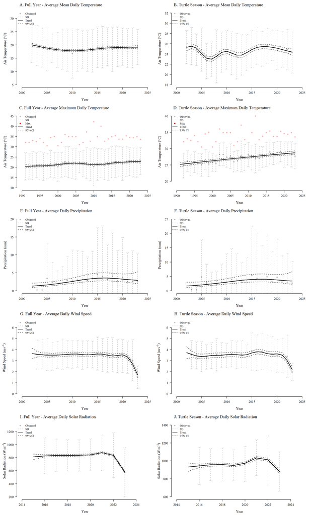

Within the turtle nesting season, Bald Head Island has experienced significant annual increases in maximum daily air temperatures (0.111 $^\circ C$ yr<sup>-1</sup>, p << 0.001). A smaller increase was observed in average daily temperatures (0.031 $^\circ C$ yr<sup>-1</sup>, p < 0.001). Precipitation has been trending up (0.103 mm yr<sup>-1</sup>) but the GAM p value is marginal (p = 0.08), and worth further investigation.

Solar radiation has been on an increasingly downward trend since 2021 (GAM p = 0.034).

Annual wind speed showed no positive or negative linear trend (-0.014 m s<sup>-1</sup>, p = 0.287) but there are shorter trends visible within, including a rapid drop since 2020 (GAM p < 0.001).

**Average Air Temperature**

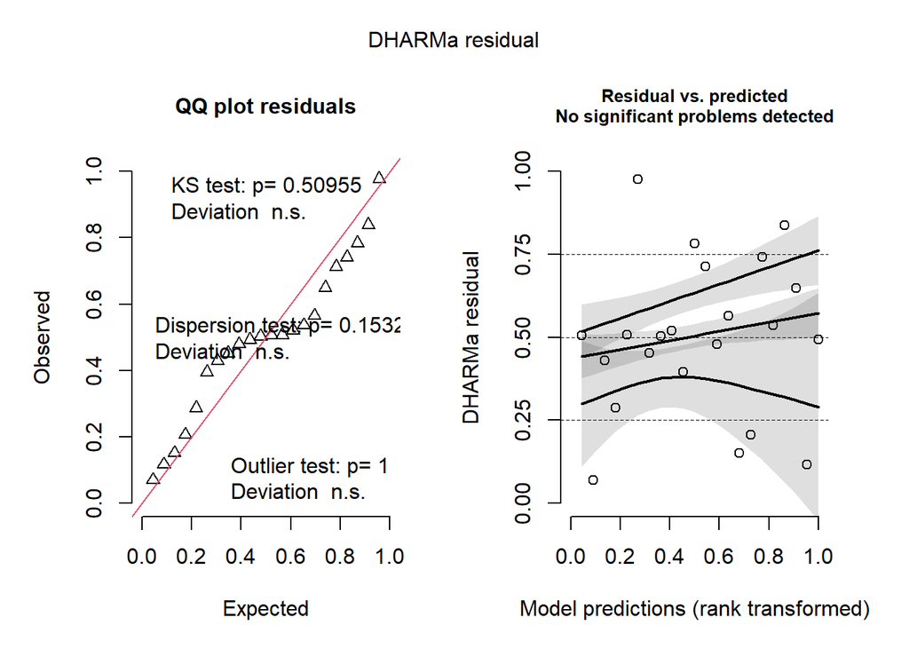

```
##
## Family: gaussian
## Link function: identity
##
## Formula:
## meanAvgAir ~ s(year)
##
## Parametric coefficients:
##             Estimate Std. Error t value Pr(>|t|)
## (Intercept) 24.56182    0.07741   317.3   <2e-16 ***
## ---
## Signif. codes:  0 '***' 0.001 '**' 0.01 '*' 0.05 '.' 0.1 ' ' 1
##
## Approximate significance of smooth terms:
##           edf Ref.df     F  p-value
## s(year) 8.485  8.925 10.41 0.000118 ***
## ---
## Signif. codes:  0 '***' 0.001 '**' 0.01 '*' 0.05 '.' 0.1 ' ' 1
##
## R-sq.(adj) =  0.811   Deviance explained = 88.7%
## GCV = 0.23173  Scale est. = 0.13182   n = 22
```

```
## [1] "Linear estimation of average air temperature (°C) increase per year: 0.031"
```

**Maximum Air Temperature**

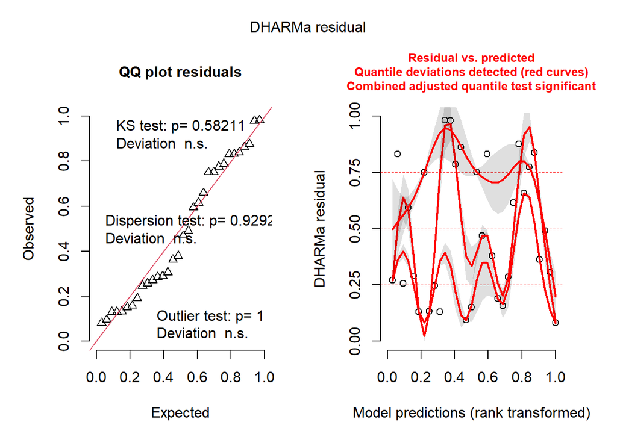

```
##
## Family: gaussian
## Link function: identity
##
## Formula:
## meanMaxAir ~ s(year)
##
## Parametric coefficients:
##             Estimate Std. Error t value Pr(>|t|)
## (Intercept)  27.1056     0.1378   196.7   <2e-16 ***
## ---
## Signif. codes:  0 '***' 0.001 '**' 0.01 '*' 0.05 '.' 0.1 ' ' 1
##
## Approximate significance of smooth terms:
##           edf Ref.df     F  p-value
## s(year) 1.312  1.559 33.67 2.33e-07 ***
## ---
## Signif. codes:  0 '***' 0.001 '**' 0.01 '*' 0.05 '.' 0.1 ' ' 1
##
## R-sq.(adj) =  0.639   Deviance explained = 65.4%
## GCV = 0.65515  Scale est. = 0.60783   n = 32
```

```
## [1] "Linear estimation of average air temperature (°C) increase per year: 0.111"
```

**Average Daily Precipitation**

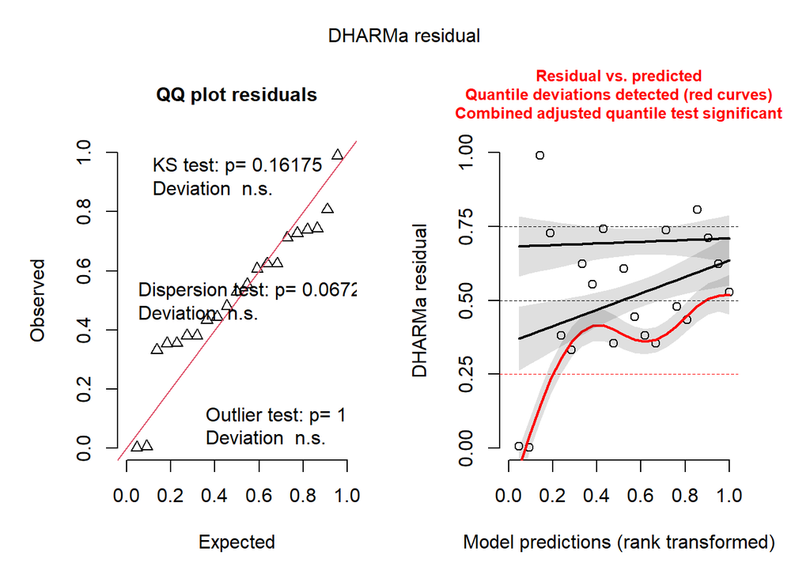

```
##
## Family: Gamma
## Link function: inverse
##
## Formula:
## meanPrecip ~ s(year)
##
## Parametric coefficients:
##             Estimate Std. Error t value Pr(>|t|)
## (Intercept)  0.33185    0.03355   9.892    1e-08 ***
## ---
## Signif. codes:  0 '***' 0.001 '**' 0.01 '*' 0.05 '.' 0.1 ' ' 1
##
## Approximate significance of smooth terms:
##           edf Ref.df     F p-value
## s(year) 1.902  2.384 2.726  0.0845 .
## ---
## Signif. codes:  0 '***' 0.001 '**' 0.01 '*' 0.05 '.' 0.1 ' ' 1
##
## R-sq.(adj) =  0.388   Deviance explained = 27.5%
## GCV = 0.3206  Scale est. = 0.2074    n = 21
```

```
## [1] "Linear estimation of average precipitation (mm) increase per year: 0.103"
```

**Average Daily Wind Speed**

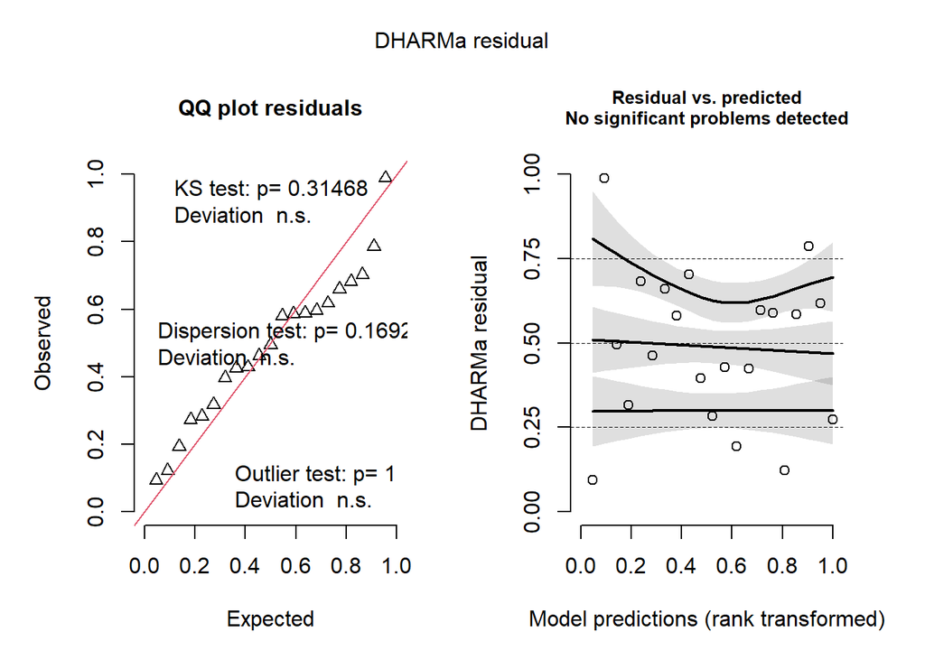

```
##
## Family: gaussian
## Link function: identity
##
## Formula:
## meanWindSpeed ~ s(year)
##
## Parametric coefficients:
##             Estimate Std. Error t value Pr(>|t|)
## (Intercept)  3.46905    0.03614   95.98   <2e-16 ***
## ---
## Signif. codes:  0 '***' 0.001 '**' 0.01 '*' 0.05 '.' 0.1 ' ' 1
##
## Approximate significance of smooth terms:
##           edf Ref.df     F  p-value
## s(year) 8.154  8.806 9.221 0.000341 ***
## ---
## Signif. codes:  0 '***' 0.001 '**' 0.01 '*' 0.05 '.' 0.1 ' ' 1
##
## R-sq.(adj) =  0.797   Deviance explained =   88%
## GCV = 0.048636  Scale est. = 0.027435  n = 21
```

```
##
## Call:
## lm(formula = meanWindSpeed ~ year, data = BHI_Year_Turtle)
##
## Residuals:
##      Min       1Q   Median       3Q      Max
## -1.34463 -0.08346  0.03651  0.12207  0.41872
##
## Coefficients:
##             Estimate Std. Error t value Pr(>|t|)
## (Intercept) 32.53990   26.53552   1.226    0.235
## year        -0.01444    0.01318  -1.096    0.287
##
## Residual standard error: 0.3658 on 19 degrees of freedom
##   (12 observations deleted due to missingness)
## Multiple R-squared:  0.05942,    Adjusted R-squared:  0.009912
## F-statistic:   1.2 on 1 and 19 DF,  p-value: 0.287
```

**Average Maximum Solar Radiation**

Note: too few observations of annual solar radiation to fit DHARMa model plots.

```
##
## Family: gaussian
## Link function: identity
##
## Formula:
## meanSolarRad ~ s(year, k = 7)
##
## Parametric coefficients:
##             Estimate Std. Error t value Pr(>|t|)
## (Intercept)  964.799      3.336   289.2 8.79e-05 ***
## ---
## Signif. codes:  0 '***' 0.001 '**' 0.01 '*' 0.05 '.' 0.1 ' ' 1
##
## Approximate significance of smooth terms:
##           edf Ref.df     F p-value
## s(year) 5.393  5.854 28.97  0.0338 *
## ---
## Signif. codes:  0 '***' 0.001 '**' 0.01 '*' 0.05 '.' 0.1 ' ' 1
##
## R-sq.(adj) =   0.96   Deviance explained = 99.1%
## GCV = 443.11  Scale est. = 89.03     n = 8
```

```
## [1] "Linear estimation of average solar radiation (W m-2) increase per year: 1.096"
```

# 6 MONTHLY AND WEEKLY MEANS

Using the above time series, monthly and weekly means for each available variable were calculated across the full year. For some variables (e.g., maximum daily air temperature), the record is sufficiently long as to be representative of a climatology. Other variables (e.g., solar radiation), need more time before reaching this threshold.

## 6.1 By Month

Monthly meteorological conditions for Bald Head Island from 1991 - 2023

| month | meanAvgAir | sdAvgAir | missAvgTemp | meanMaxAir | sdMaxAir | maxMaxAir | missMaxTemp | meanPrecip | sdPrecip | maxPrecip | missPrecip | meanWindSpeed | sdWindSpeed | maxWindSpeed | meanWindDir | missWind | meanSolarRad | sdSolarRad | missSolarRad |
| --- | --- | --- | --- | --- | --- | --- | --- | --- | --- | --- | --- | --- | --- | --- | --- | --- | --- | --- | --- |
| 1 | 8.97 | 5.23 | 35.9 | 12.57 | 5.22 | 24.2 | 1.0 | 2.16 | 6.59 | 87.63 | 36.4 | 3.27 | 1.49 | 8.10 | 267.54 | 36.6 | 516.78 | 210.85 | 77.2 |
| 2 | 10.21 | 4.14 | 33.5 | 13.80 | 4.45 | 24.9 | 0.5 | 2.47 | 6.62 | 90.17 | 36.3 | 3.48 | 1.49 | 9.09 | 271.68 | 36.5 | 633.40 | 256.77 | 76.4 |
| 3 | 13.82 | 4.37 | 33.3 | 17.33 | 4.54 | 37.2 | 0.6 | 2.21 | 6.12 | 61.03 | 33.9 | 3.56 | 1.36 | 9.25 | 225.28 | 35.3 | 782.06 | 312.15 | 76.0 |
| 4 | 18.19 | 3.39 | 34.0 | 21.40 | 3.62 | 32.9 | 3.8 | 2.21 | 7.31 | 94.74 | 34.3 | 3.71 | 1.46 | 8.90 | 212.10 | 34.9 | 867.55 | 341.48 | 76.6 |
| 5 | 22.29 | 3.08 | 34.1 | 24.99 | 3.22 | 40.0 | 3.6 | 2.32 | 6.79 | 76.71 | 34.6 | 3.64 | 1.24 | 9.60 | 201.24 | 34.6 | 1024.38 | 190.85 | 76.1 |
| 6 | 26.01 | 2.26 | 35.1 | 28.20 | 2.84 | 40.0 | 2.0 | 2.75 | 7.68 | 111.51 | 36.1 | 3.71 | 1.32 | 8.60 | 207.45 | 36.1 | 1063.01 | 164.62 | 76.0 |
| 7 | 27.50 | 1.76 | 36.6 | 29.77 | 2.34 | 42.2 | 3.2 | 2.95 | 8.50 | 73.91 | 38.4 | 3.81 | 1.56 | 9.70 | 214.74 | 38.4 | 1042.53 | 153.99 | 73.9 |
| 8 | 27.06 | 1.91 | 33.5 | 29.36 | 2.46 | 37.2 | 1.7 | 4.22 | 10.58 | 94.98 | 34.0 | 3.27 | 1.32 | 9.65 | 197.24 | 34.1 | 989.59 | 183.32 | 74.0 |
| 9 | 24.75 | 2.48 | 35.4 | 27.24 | 2.68 | 34.4 | 6.7 | 4.04 | 13.49 | 157.48 | 35.4 | 3.34 | 1.52 | 14.90 | 81.32 | 35.5 | 889.85 | 209.36 | 74.5 |
| 10 | 19.89 | 4.02 | 33.7 | 23.04 | 3.54 | 31.9 | 0.8 | 2.65 | 10.75 | 145.03 | 33.9 | 3.05 | 1.35 | 8.40 | 26.20 | 33.9 | 753.46 | 176.46 | 73.9 |
| 11 | 14.31 | 4.68 | 33.4 | 18.22 | 4.41 | 28.8 | 1.4 | 2.25 | 6.99 | 80.77 | 33.4 | 3.03 | 1.43 | 9.56 | 350.98 | 33.6 | 583.36 | 186.62 | 74.7 |
| 12 | 11.02 | 4.72 | 33.3 | 14.36 | 4.74 | 25.5 | 0.0 | 2.33 | 6.18 | 59.18 | 33.3 | 3.08 | 1.45 | 9.10 | 273.39 | 33.4 | 485.98 | 185.63 | 75.1 |

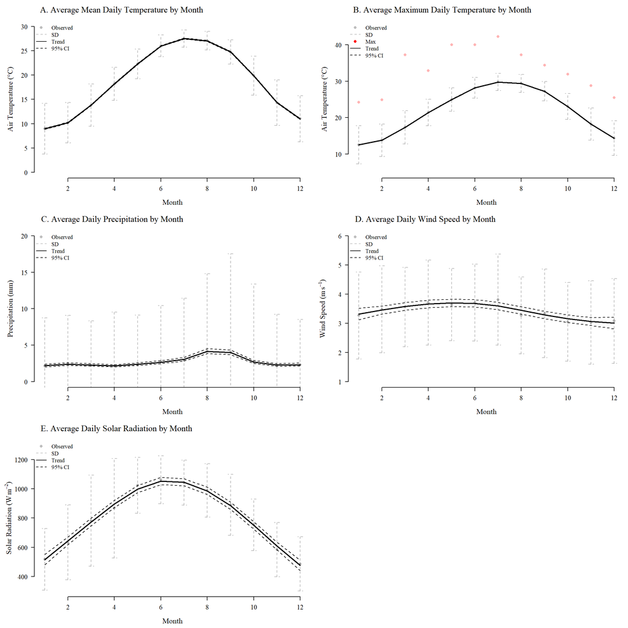

## 6.2 By Week

Weekly meteorological conditions for Bald Head Island from 1991 - 2023

| week | meanAvgAir | sdAvgAir | missAvgTemp | meanMaxAir | sdMaxAir | maxMaxAir | missMaxTemp | meanPrecip | sdPrecip | maxPrecip | missPrecip | meanWindSpeed | sdWindSpeed | maxWindSpeed | meanWindDir | missWind | meanSolarRad | sdSolarRad | missSolarRad |
| --- | --- | --- | --- | --- | --- | --- | --- | --- | --- | --- | --- | --- | --- | --- | --- | --- | --- | --- | --- |
| 1 | 10.05 | 6.08 | 38.2 | 12.77 | 5.54 | 22.1 | 3.1 | 2.48 | 5.16 | 24.89 | 35.1 | 3.04 | 1.46 | 6.40 | 253.22 | 35.1 | 402.65 | 194.16 | 74.0 |
| 2 | 9.97 | 5.62 | 38.5 | 13.61 | 5.41 | 22.7 | 2.2 | 1.43 | 4.19 | 31.24 | 36.4 | 3.24 | 1.53 | 7.19 | 245.03 | 36.4 | 531.44 | 196.69 | 77.9 |
| 3 | 9.06 | 5.26 | 35.5 | 13.08 | 5.11 | 22.7 | 0.0 | 1.42 | 4.24 | 32.26 | 36.4 | 3.08 | 1.42 | 6.89 | 282.24 | 36.4 | 543.69 | 197.91 | 77.5 |
| 4 | 8.27 | 4.64 | 33.3 | 11.67 | 5.19 | 22.6 | 0.0 | 3.38 | 10.28 | 87.63 | 36.4 | 3.50 | 1.52 | 8.00 | 272.55 | 36.4 | 514.37 | 222.58 | 77.1 |
| 5 | 8.48 | 4.68 | 33.3 | 12.12 | 4.69 | 24.2 | 0.9 | 1.97 | 4.74 | 28.70 | 36.4 | 3.39 | 1.46 | 8.10 | 270.22 | 37.2 | 548.15 | 235.61 | 78.4 |
| 6 | 9.65 | 3.69 | 33.8 | 12.94 | 4.20 | 21.6 | 0.9 | 3.31 | 9.80 | 90.17 | 36.8 | 3.49 | 1.42 | 9.00 | 278.75 | 36.8 | 624.71 | 222.67 | 76.6 |
| 7 | 9.75 | 4.13 | 33.3 | 13.27 | 4.42 | 24.9 | 0.4 | 2.31 | 6.25 | 58.93 | 37.2 | 3.42 | 1.56 | 9.09 | 267.79 | 37.2 | 606.09 | 251.03 | 76.2 |
| 8 | 10.42 | 4.71 | 33.3 | 14.19 | 4.66 | 23.9 | 0.0 | 2.45 | 6.21 | 34.04 | 36.4 | 3.44 | 1.44 | 6.80 | 291.43 | 36.8 | 598.47 | 285.13 | 75.8 |
| 9 | 11.46 | 4.06 | 33.3 | 15.13 | 4.47 | 27.7 | 0.0 | 1.85 | 3.90 | 19.38 | 33.8 | 3.61 | 1.53 | 8.34 | 258.27 | 35.1 | 691.29 | 257.62 | 75.8 |
| 10 | 11.39 | 4.54 | 33.3 | 15.62 | 4.71 | 30.4 | 0.4 | 2.46 | 5.61 | 31.42 | 35.1 | 3.65 | 1.49 | 9.25 | 271.30 | 36.8 | 759.58 | 283.26 | 75.8 |
| 11 | 13.81 | 3.93 | 33.3 | 17.19 | 4.25 | 26.0 | 0.0 | 1.68 | 5.39 | 40.97 | 33.8 | 3.52 | 1.34 | 7.51 | 225.73 | 35.9 | 757.75 | 313.63 | 75.8 |
| 12 | 14.16 | 4.14 | 33.3 | 17.32 | 4.61 | 37.2 | 0.4 | 1.82 | 4.58 | 30.99 | 33.8 | 3.32 | 1.27 | 6.82 | 108.96 | 34.6 | 787.80 | 319.73 | 76.2 |
| 13 | 15.39 | 3.94 | 33.3 | 18.58 | 4.14 | 29.9 | 2.2 | 2.07 | 5.66 | 43.43 | 33.3 | 3.60 | 1.37 | 7.10 | 197.03 | 33.8 | 819.32 | 340.96 | 76.2 |
| 14 | 16.01 | 3.88 | 33.8 | 19.48 | 3.93 | 32.2 | 3.9 | 3.84 | 9.16 | 61.03 | 35.5 | 3.87 | 1.49 | 8.30 | 222.25 | 36.4 | 852.47 | 346.46 | 76.2 |
| 15 | 17.36 | 3.16 | 33.3 | 20.65 | 3.53 | 31.5 | 3.0 | 1.46 | 3.57 | 26.16 | 33.3 | 3.60 | 1.42 | 7.20 | 217.05 | 33.8 | 846.71 | 324.19 | 75.8 |
| 16 | 18.23 | 3.47 | 33.3 | 21.73 | 3.50 | 32.8 | 3.0 | 2.37 | 7.21 | 56.59 | 33.3 | 3.82 | 1.68 | 8.90 | 188.59 | 33.3 | 871.48 | 344.30 | 75.8 |
| 17 | 19.06 | 2.85 | 34.2 | 22.13 | 3.22 | 32.4 | 3.9 | 2.85 | 11.03 | 94.74 | 34.2 | 3.72 | 1.29 | 8.16 | 212.65 | 35.5 | 866.55 | 359.82 | 77.5 |
| 18 | 20.31 | 2.84 | 36.4 | 22.99 | 3.29 | 32.9 | 4.3 | 1.30 | 4.05 | 27.95 | 35.5 | 3.73 | 1.29 | 8.10 | 216.33 | 35.5 | 1000.72 | 173.36 | 77.9 |
| 19 | 21.30 | 2.99 | 33.3 | 24.08 | 3.22 | 32.7 | 3.5 | 2.25 | 6.47 | 43.03 | 34.6 | 3.74 | 1.36 | 8.51 | 213.13 | 34.6 | 1054.27 | 129.76 | 75.8 |
| 20 | 21.75 | 2.86 | 33.3 | 24.41 | 2.83 | 31.7 | 3.0 | 2.28 | 6.62 | 56.59 | 34.6 | 3.64 | 1.14 | 7.79 | 201.76 | 34.6 | 1013.59 | 236.10 | 75.8 |
| 21 | 22.55 | 2.84 | 33.3 | 25.45 | 3.06 | 37.2 | 3.0 | 3.17 | 8.55 | 76.71 | 33.3 | 3.67 | 1.25 | 9.60 | 188.20 | 33.3 | 1005.66 | 207.75 | 76.2 |
| 22 | 24.32 | 2.78 | 35.5 | 26.76 | 3.06 | 40.0 | 4.8 | 1.87 | 6.15 | 60.96 | 35.9 | 3.52 | 1.13 | 7.30 | 195.74 | 35.9 | 1013.12 | 188.75 | 76.2 |
| 23 | 24.73 | 2.31 | 35.9 | 26.99 | 3.00 | 40.0 | 3.9 | 2.88 | 6.64 | 53.87 | 35.9 | 3.56 | 1.18 | 8.30 | 198.68 | 35.9 | 1049.93 | 174.04 | 76.6 |
| 24 | 25.58 | 2.27 | 35.5 | 27.66 | 2.71 | 34.9 | 2.2 | 2.90 | 8.48 | 55.63 | 37.7 | 3.67 | 1.19 | 6.60 | 198.45 | 37.7 | 1049.86 | 202.20 | 76.2 |
| 25 | 26.36 | 2.15 | 34.6 | 28.49 | 2.85 | 37.2 | 1.3 | 3.52 | 10.52 | 111.51 | 34.6 | 3.68 | 1.26 | 8.00 | 209.56 | 34.6 | 1063.77 | 151.73 | 77.1 |
| 26 | 26.85 | 1.68 | 34.6 | 29.07 | 2.41 | 38.9 | 1.3 | 1.81 | 4.08 | 23.07 | 35.9 | 3.91 | 1.57 | 8.60 | 216.21 | 35.9 | 1088.56 | 125.20 | 75.3 |
| 27 | 26.94 | 1.77 | 34.6 | 29.23 | 2.26 | 35.2 | 1.3 | 2.73 | 8.58 | 72.20 | 37.7 | 3.61 | 1.56 | 7.70 | 211.27 | 37.7 | 1056.50 | 141.59 | 75.8 |
| 28 | 27.29 | 1.77 | 37.2 | 29.61 | 2.48 | 42.2 | 3.9 | 2.73 | 7.92 | 71.37 | 40.3 | 3.88 | 1.67 | 8.30 | 214.23 | 40.3 | 1060.23 | 173.12 | 73.2 |
| 29 | 27.74 | 1.56 | 38.5 | 29.96 | 2.34 | 36.0 | 5.2 | 3.51 | 10.10 | 73.91 | 39.4 | 3.70 | 1.38 | 7.15 | 215.31 | 39.4 | 1023.31 | 185.10 | 73.2 |
| 30 | 27.65 | 1.63 | 36.4 | 29.95 | 2.09 | 34.7 | 3.0 | 2.68 | 6.56 | 44.70 | 37.2 | 3.84 | 1.58 | 9.70 | 216.27 | 37.2 | 1063.96 | 144.71 | 73.6 |
| 31 | 27.61 | 1.76 | 34.2 | 29.71 | 2.58 | 35.4 | 0.9 | 3.97 | 11.35 | 86.95 | 35.1 | 3.73 | 1.48 | 8.30 | 209.00 | 35.1 | 1000.80 | 155.95 | 74.0 |
| 32 | 27.31 | 1.82 | 33.3 | 29.56 | 2.54 | 37.2 | 0.0 | 4.58 | 10.63 | 76.20 | 33.3 | 3.56 | 1.43 | 7.70 | 207.05 | 33.3 | 1000.63 | 174.30 | 74.0 |
| 33 | 27.32 | 2.09 | 34.2 | 29.67 | 2.44 | 34.4 | 1.3 | 2.78 | 7.07 | 41.15 | 35.5 | 3.43 | 1.32 | 8.10 | 203.34 | 35.5 | 1015.46 | 109.45 | 75.8 |
| 34 | 27.15 | 2.03 | 33.3 | 29.55 | 2.42 | 35.2 | 3.9 | 3.30 | 7.26 | 49.53 | 33.8 | 3.16 | 1.24 | 7.20 | 201.01 | 33.8 | 998.60 | 170.85 | 72.7 |
| 35 | 26.44 | 1.90 | 33.3 | 28.76 | 2.36 | 33.9 | 2.2 | 5.75 | 13.80 | 94.98 | 33.8 | 3.02 | 1.28 | 9.65 | 159.77 | 33.8 | 974.63 | 196.57 | 73.2 |
| 36 | 26.34 | 1.91 | 33.3 | 28.67 | 2.48 | 34.4 | 3.0 | 3.66 | 15.75 | 157.48 | 33.3 | 3.26 | 1.38 | 9.40 | 135.36 | 34.2 | 935.45 | 201.78 | 74.0 |
| 37 | 25.60 | 1.95 | 33.8 | 27.83 | 2.50 | 33.7 | 3.5 | 4.00 | 14.04 | 140.97 | 33.8 | 3.51 | 1.70 | 14.90 | 107.94 | 33.8 | 910.17 | 200.86 | 73.6 |
| 38 | 24.26 | 2.28 | 37.7 | 27.11 | 2.17 | 33.1 | 8.2 | 3.29 | 10.07 | 99.10 | 36.4 | 3.45 | 1.60 | 12.06 | 55.27 | 36.4 | 888.09 | 245.47 | 75.8 |
| 39 | 23.56 | 2.66 | 37.2 | 26.12 | 2.92 | 32.1 | 10.0 | 3.56 | 9.81 | 65.28 | 38.1 | 3.08 | 1.39 | 9.53 | 73.37 | 38.1 | 862.68 | 221.85 | 75.3 |
| 40 | 23.36 | 2.66 | 33.8 | 25.81 | 2.84 | 32.2 | 4.3 | 4.58 | 13.81 | 83.81 | 35.1 | 3.18 | 1.29 | 8.80 | 81.21 | 35.1 | 827.78 | 169.32 | 74.0 |
| 41 | 21.35 | 3.64 | 34.2 | 24.25 | 3.13 | 30.9 | 1.3 | 5.06 | 18.23 | 145.03 | 34.2 | 3.21 | 1.37 | 8.40 | 59.44 | 34.2 | 724.94 | 236.11 | 74.5 |
| 42 | 20.35 | 2.97 | 33.8 | 23.32 | 2.93 | 30.2 | 1.7 | 1.61 | 4.43 | 35.05 | 33.8 | 2.99 | 1.25 | 7.60 | 316.59 | 33.8 | 806.12 | 128.37 | 73.2 |
| 43 | 18.25 | 4.04 | 33.3 | 21.92 | 3.56 | 27.7 | 0.0 | 1.95 | 6.82 | 50.55 | 33.3 | 2.91 | 1.30 | 8.18 | 312.38 | 33.3 | 743.04 | 109.84 | 73.6 |
| 44 | 17.34 | 4.40 | 33.3 | 21.13 | 3.71 | 29.9 | 0.0 | 2.11 | 8.02 | 78.23 | 33.3 | 3.11 | 1.54 | 8.10 | 296.29 | 33.3 | 701.43 | 178.26 | 73.2 |
| 45 | 16.24 | 4.70 | 33.3 | 19.68 | 4.20 | 28.8 | 0.4 | 2.05 | 6.38 | 55.88 | 33.3 | 3.06 | 1.32 | 7.47 | 14.69 | 33.3 | 602.55 | 177.84 | 74.0 |
| 46 | 14.85 | 4.50 | 33.3 | 18.40 | 4.34 | 26.8 | 2.2 | 2.99 | 9.50 | 80.77 | 33.3 | 3.22 | 1.41 | 7.14 | 18.07 | 33.3 | 602.81 | 206.38 | 74.0 |
| 47 | 13.33 | 4.19 | 33.3 | 17.65 | 4.17 | 26.1 | 2.6 | 2.05 | 6.30 | 41.40 | 33.3 | 3.01 | 1.50 | 8.52 | 353.75 | 34.2 | 572.18 | 173.35 | 74.9 |
| 48 | 12.82 | 4.68 | 33.8 | 17.08 | 4.62 | 27.7 | 0.9 | 1.72 | 5.28 | 41.83 | 33.8 | 2.80 | 1.47 | 9.56 | 272.61 | 33.8 | 529.14 | 177.23 | 76.6 |
| 49 | 12.02 | 4.28 | 33.3 | 16.08 | 4.10 | 23.1 | 0.0 | 1.89 | 4.63 | 33.27 | 33.3 | 2.98 | 1.36 | 8.00 | 274.69 | 33.3 | 508.02 | 188.95 | 74.0 |
| 50 | 11.26 | 4.74 | 33.3 | 15.17 | 4.80 | 25.5 | 0.0 | 2.35 | 5.55 | 32.51 | 33.3 | 3.04 | 1.46 | 7.28 | 280.75 | 33.3 | 464.73 | 179.58 | 75.8 |
| 51 | 11.08 | 4.32 | 33.3 | 14.13 | 4.33 | 22.7 | 0.0 | 2.65 | 7.53 | 59.18 | 33.3 | 3.24 | 1.53 | 9.10 | 261.16 | 33.8 | 507.85 | 187.42 | 74.9 |
| 52 | 10.25 | 5.15 | 33.3 | 13.40 | 4.74 | 23.2 | 0.0 | 3.05 | 7.66 | 41.91 | 33.3 | 3.14 | 1.37 | 7.90 | 284.96 | 33.3 | 445.58 | 208.36 | 75.8 |
| 53 | 11.01 | 5.28 | 35.0 | 13.16 | 5.24 | 23.5 | 0.0 | 1.52 | 3.55 | 20.69 | 35.0 | 3.01 | 1.61 | 6.77 | 255.33 | 35.0 | 515.24 | 140.00 | 75.7 |

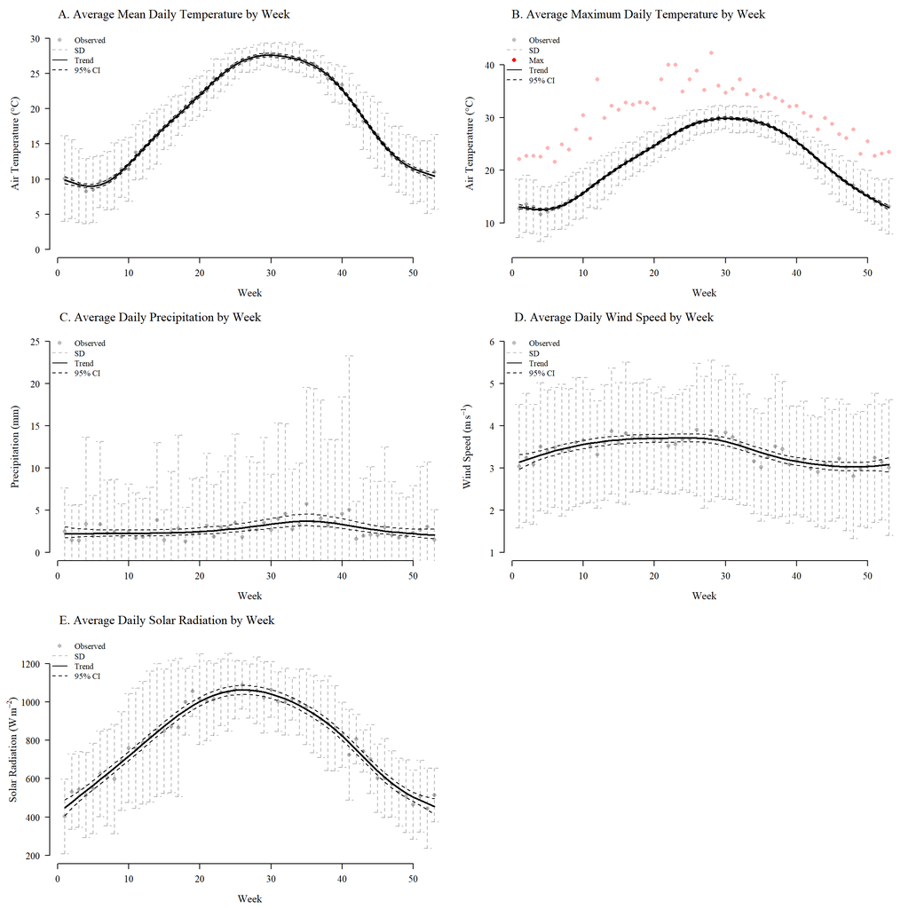

# 7 REFERENCES

```
## Analyses were conducted using the R Statistical language
## (version 4.3.2; R Core Team, 2023) on Windows 10 x64 (build
## 19045), using the packages leaflet (version 2.2.1; Cheng J
## et al., 2023), rWind (version 1.1.7; Fernández-López J,
## Schliep K, 2019), janitor (version 2.2.0; Firke S, 2023),
## report (version 0.5.8; Makowski D et al., 2023), sf
## (version 1.0.15; Pebesma E, Bivand R, 2023), nlme (version
## 3.1.164; Pinheiro J et al., 2023), tmap (version 3.3.4;
## Tennekes M, 2018), tmaptools (version 3.1.1; Tennekes M,
## 2021), readxl (version 1.4.3; Wickham H, Bryan J, 2023),
## dplyr (version 1.1.4; Wickham H et al., 2023), mgcv
## (version 1.9.1; Wood SN, 2011) and knitr (version 1.45; Xie
## Y, 2023).
##
## References
## ----------
##   - Cheng J, Schloerke B, Karambelkar B, Xie Y (2023).
## _leaflet: Create Interactive Web Maps with the JavaScript
## 'Leaflet' Library_. R package version 2.2.1,
## <https://CRAN.R-project.org/package=leaflet>.
##   - Fernández-López J, Schliep K (2019). "rWind: Download,
## edit and include wind data in ecological and evolutionary
## analysis." _Ecography_, *42*(4), 804-810.
## <https://doi.org/10.1111/ecog.03730>.
##   - Firke S (2023). _janitor: Simple Tools for Examining and
## Cleaning Dirty Data_. R package version 2.2.0,
## <https://CRAN.R-project.org/package=janitor>.
##   - Makowski D, Lüdecke D, Patil I, Thériault R, Ben-Shachar
## M, Wiernik B (2023). "Automated Results Reporting as a
## Practical Tool to Improve Reproducibility and
## Methodological Best Practices Adoption." _CRAN_.
## <https://easystats.github.io/report/>.
##   - Pebesma E, Bivand R (2023). _Spatial Data Science: With
## applications in R_. Chapman and Hall/CRC.
## doi:10.1201/9780429459016
## <https://doi.org/10.1201/9780429459016>,
## <https://r-spatial.org/book/>. Pebesma E (2018). "Simple
## Features for R: Standardized Support for Spatial Vector
## Data." _The R Journal_, *10*(1), 439-446.
## doi:10.32614/RJ-2018-009
```

[output cut: 34 more lines]

```
## *99*(467), 673-686. Wood S (2017). _Generalized Additive
## Models: An Introduction with R_, 2 edition. Chapman and
## Hall/CRC. Wood SN (2003). "Thin-plate regression splines."
## _Journal of the Royal Statistical Society (B)_, *65*(1),
## 95-114.
##   - Xie Y (2023). _knitr: A General-Purpose Package for
## Dynamic Report Generation in R_. R package version 1.45,
## <https://yihui.org/knitr/>. Xie Y (2015). _Dynamic
## Documents with R and knitr_, 2nd edition. Chapman and
## Hall/CRC, Boca Raton, Florida. ISBN 978-1498716963,
## <https://yihui.org/knitr/>. Xie Y (2014). "knitr: A
## Comprehensive Tool for Reproducible Research in R." In
## Stodden V, Leisch F, Peng RD (eds.), _Implementing
## Reproducible Computational Research_. Chapman and Hall/CRC.
## ISBN 978-1466561595.
```